# Exploratory_Factor_Analysis

03/15/2023

## Importing the complete college dataset

```r
library(psych)

clg <- read.csv("/Users//ajayvishnu/Desktop/RUTGERS/Spring 2023/Multivariate Analysis/Datasets/College_Data.csv", row.names=1)

attach(clg)
```

- Apps - Number of applications received
- Accept - Number of applications accepted
- Enroll - Number of new students enrolled
- Top10perc - Pct. new students from top 10% of H.S. class
- Top25perc - Pct. new students from top 25% of H.S. class
- F.Undergrad - Number of full-time undergraduates
- P.Undergrad - Number of part-time undergraduates
- Outstate - Out-of-state tuition
- Room.Board - Room and board costs
- Books - Estimated book costs
- Personal - Estimated personal spending
- PhD - Pct. of faculty with Ph.D.’s
- Terminal - Pct. of faculty with terminal degree
- S.F.Ratio - Student/faculty ratio
- perc.alumni - Pct. alumni who donate
- Expend - Instructional expenditure per student
- Grad_Rate - Graduation rate

## Using the varimax method

#### RC values, h2 & u2 values

```r
fit.pc <- principal(clg[-1], nfactors=4, rotate="varimax")
fit.pc
```

```
## Principal Components Analysis
## Call: principal(r = clg[-1], nfactors = 4, rotate = "varimax")
## Standardized loadings (pattern matrix) based upon correlation matrix
##               RC1   RC2   RC4   RC3   h2    u2 com
## Apps         0.18  0.93  0.12  0.05 0.91 0.086 1.1
## Accept       0.05  0.96  0.10  0.04 0.94 0.061 1.0
## Enroll      -0.07  0.95  0.15  0.09 0.93 0.066 1.1
## Top10perc    0.70  0.17  0.45 -0.01 0.72 0.282 1.8
## Top25perc    0.61  0.22  0.50 -0.04 0.67 0.334 2.2
## F.Undergrad -0.14  0.93  0.18  0.13 0.93 0.074 1.2
## P.Undergrad -0.31  0.50  0.19  0.33 0.50 0.503 2.9
## Outstate     0.84 -0.12  0.19 -0.12 0.77 0.228 1.2
## Room.Board   0.69  0.04  0.09  0.04 0.48 0.517 1.1
## Books        0.24  0.08 -0.10  0.71 0.58 0.417 1.3
## Personal    -0.28  0.18  0.10  0.67 0.57 0.427 1.6
## PhD          0.27  0.24  0.86 -0.03 0.87 0.126 1.4
## Terminal     0.30  0.21  0.84  0.03 0.83 0.166 1.4
## S.F.Ratio   -0.70  0.25  0.01 -0.14 0.57 0.432 1.3
## perc.alumni  0.59 -0.21  0.21 -0.29 0.53 0.473 2.0
## Expend       0.78  0.06  0.25  0.14 0.70 0.302 1.3
## Grad.Rate    0.68  0.07  0.08 -0.36 0.60 0.401 1.6
##
##                        RC1  RC2  RC4  RC3
## SS loadings           4.40 4.14 2.19 1.37
## Proportion Var        0.26 0.24 0.13 0.08
## Cumulative Var        0.26 0.50 0.63 0.71
## Proportion Explained  0.36 0.34 0.18 0.11
## Cumulative Proportion 0.36 0.71 0.89 1.00
##
## Mean item complexity =  1.5
## Test of the hypothesis that 4 components are sufficient.
##
## The root mean square of the residuals (RMSR) is  0.06
##  with the empirical chi square  854.74  with prob <  3.7e-133
##
## Fit based upon off diagonal values = 0.97
```

- h2 - Explained variance
- u2 - Unexplained variance
- h2 nd u2 add up to 1
- The Proportion explained shows us the PCA values

#### Eigen Values

```r
fit.pc$values
```

```
##  [1] 5.44350679 4.47783645 1.17315581 1.00690817 0.93302887 0.84739916
##  [7] 0.60500815 0.58711563 0.52992973 0.40378256 0.31304247 0.22032704
## [13] 0.16757820 0.14379320 0.08791135 0.03667818 0.02299823
```

```r
round(fit.pc$values, 3)
```

```
##  [1] 5.444 4.478 1.173 1.007 0.933 0.847 0.605 0.587 0.530 0.404 0.313 0.220
## [13] 0.168 0.144 0.088 0.037 0.023
```

- The above are the eigen values.

#### Clubbing columns to RCs

```r
fit.pc$loadings
```

```
##
## Loadings:
##             RC1    RC2    RC4    RC3
## Apps         0.183  0.929  0.122
## Accept              0.962
## Enroll              0.947  0.152
## Top10perc    0.699  0.170  0.446
## Top25perc    0.607  0.216  0.499
## F.Undergrad -0.141  0.926  0.177  0.133
## P.Undergrad -0.313  0.500  0.194  0.334
## Outstate     0.841 -0.118  0.192 -0.115
## Room.Board   0.686
## Books        0.238                0.714
## Personal    -0.282  0.183         0.671
## PhD          0.270  0.240  0.862
## Terminal     0.300  0.213  0.835
## S.F.Ratio   -0.696  0.254        -0.138
## perc.alumni  0.594 -0.207  0.214 -0.292
## Expend       0.781         0.254  0.140
## Grad.Rate    0.678               -0.357
##
##                  RC1   RC2   RC4   RC3
## SS loadings    4.401 4.142 2.186 1.373
## Proportion Var 0.259 0.244 0.129 0.081
## Cumulative Var 0.259 0.503 0.631 0.712
```

- We need to look for values over 0.5
- RC1 shows relation with Outstate, Expend, Top10perc, Room.Board, Grad.Rate, Top25perc, perc.alumni and negative with S.F.Ratio
- RC2 shows relation with Accept, Enroll, Apps, F.Undergrad, P.Undergrad
- RC4 shows relation with PhD and Terminal
- RC3 shows relation with Books and Personal

#### Loadings with more digits

```r
for (i in c(1,3,2,4)) { print(fit.pc$loadings[[1,i]])}
```

```
## [1] 0.1833705
## [1] 0.1219853
## [1] 0.9285571
## [1] 0.0535501
```

#### Communalities

```r
fit.pc$communality
```

```
##        Apps      Accept      Enroll   Top10perc   Top25perc F.Undergrad
##   0.9135911   0.9389044   0.9335054   0.7177440   0.6659623   0.9259139
## P.Undergrad    Outstate  Room.Board       Books    Personal         PhD
##   0.4965712   0.7718462   0.4831191   0.5830243   0.5729903   0.8736147
##    Terminal   S.F.Ratio perc.alumni      Expend   Grad.Rate
##   0.8336598   0.5676277   0.5268899   0.6979184   0.5985246
```

#### Rotated factor scores, Notice the columns ordering: RC1, RC2, RC4 and RC3

```r
fit.pc$scores
```

[output not shown]

[output cut: 1501 more lines]

[output not shown]

#### Factor Recommendation

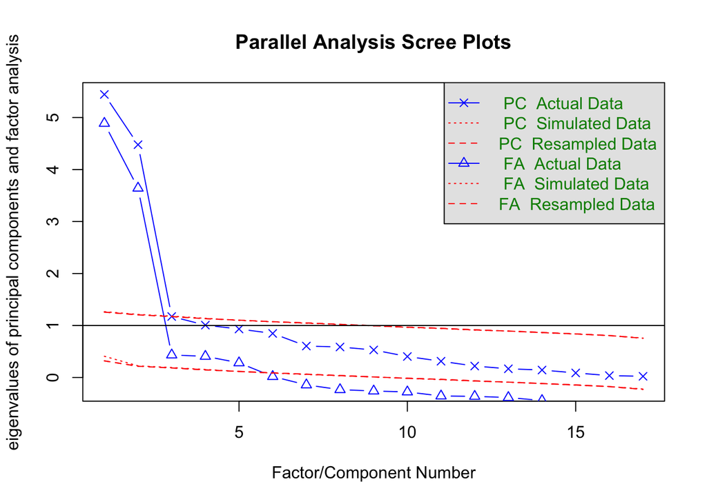

```
## Parallel analysis suggests that the number of factors =  5  and the number of components =  2
```

```r
fa.parallel(clg[-1])
```

- Plot shows elbow at 3

#### Correlations within Factors

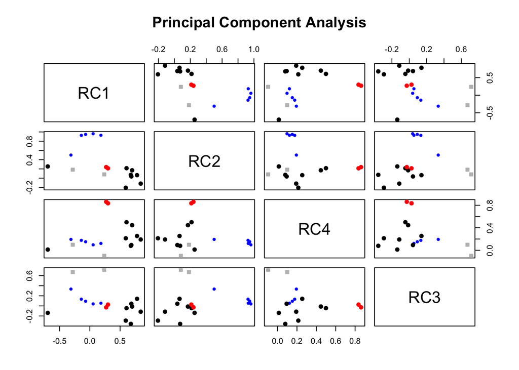

```r
fa.plot(fit.pc)
```

#### Visualizing the relationship

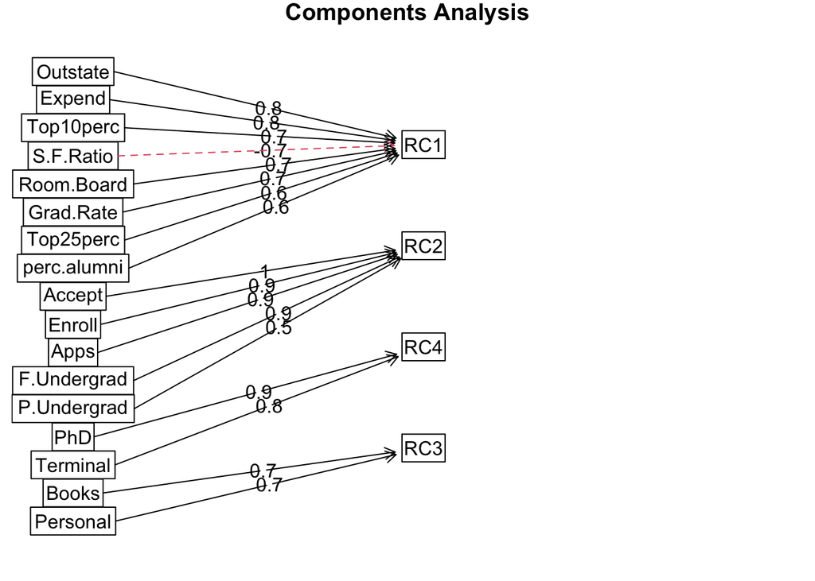

```r
fa.diagram(fit.pc)
```

- RC1 - RC1 consisted of multiple aspects and is hard to interpret
- RC2 - RC2 summed up the applications, enrollements and the students aspects of the dataset.
- RC3 - RC3 summed up the expenses part in the dataset
- RC4 - RC4 summed up the faculty in the dataset

#### Factor recommendations for a simple structure

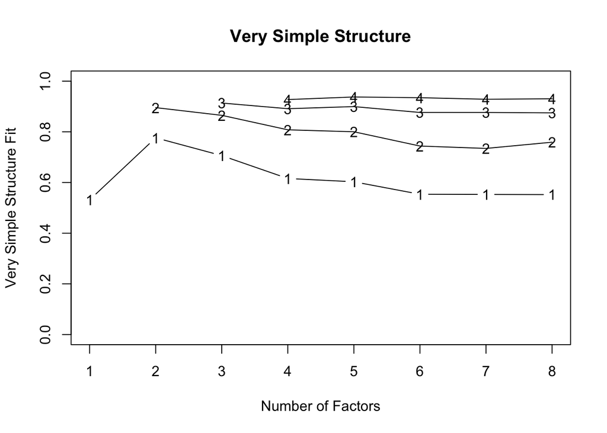

```
##
## Very Simple Structure
## Call: vss(x = clg[-1])
## VSS complexity 1 achieves a maximimum of 0.78  with  2  factors
## VSS complexity 2 achieves a maximimum of 0.9  with  2  factors
##
## The Velicer MAP achieves a minimum of 0.05  with  2  factors
## BIC achieves a minimum of  24.14  with  8  factors
## Sample Size adjusted BIC achieves a minimum of  113.05  with  8  factors
##
## Statistics by number of factors
##   vss1 vss2   map dof chisq     prob sqresid  fit RMSEA  BIC SABIC complex
## 1 0.53 0.00 0.118 119  8437  0.0e+00    25.8 0.53 0.300 7645  8023     1.0
## 2 0.78 0.90 0.050 103  3067  0.0e+00     5.7 0.90 0.192 2381  2708     1.3
## 3 0.71 0.87 0.057  88  2292  0.0e+00     4.7 0.91 0.180 1706  1986     1.4
## 4 0.62 0.81 0.053  74  1371 7.6e-238     4.0 0.93 0.150  878  1113     1.5
## 5 0.60 0.80 0.054  61  1039 8.6e-178     3.0 0.95 0.144  633   826     1.8
## 6 0.55 0.74 0.070  49   930 4.8e-163     2.5 0.95 0.152  604   759     1.9
## 7 0.55 0.73 0.089  38   340  3.9e-50     2.4 0.96 0.101   87   208     2.0
## 8 0.55 0.76 0.122  28   210  7.0e-30     1.6 0.97 0.092   24   113     1.8
##    eChisq   SRMR eCRMS  eBIC
## 1 12700.8 0.2451 0.262 11909
## 2   861.3 0.0638 0.073   176
## 3   536.9 0.0504 0.063   -49
## 4   291.5 0.0371 0.050  -201
## 5    91.5 0.0208 0.031  -314
## 6    43.4 0.0143 0.024  -283
## 7    22.5 0.0103 0.020  -230
## 8     7.1 0.0058 0.013  -179
```

```r
vss(clg[-1])
```

- Till 3 there is change, from 3 no change
- This is how we decide number of factors

## Using oblimin rotate method

#### RC values, h2 & u2 values

```r
fit.pc1 <- principal(clg[-1], nfactors=4, rotate="oblimin")
fit.pc1
```

```
## Principal Components Analysis
## Call: principal(r = clg[-1], nfactors = 4, rotate = "oblimin")
## Standardized loadings (pattern matrix) based upon correlation matrix
##               TC1   TC2   TC3   TC4   h2    u2 com
## Apps         0.58  0.70 -0.07 -0.28 0.91 0.086 2.3
## Accept       0.48  0.79 -0.11 -0.27 0.94 0.061 2.0
## Enroll       0.41  0.85 -0.09 -0.16 0.93 0.066 1.6
## Top10perc    0.83 -0.17  0.04  0.05 0.72 0.282 1.1
## Top25perc    0.80 -0.09 -0.03  0.11 0.67 0.334 1.1
## F.Undergrad  0.36  0.88 -0.07 -0.10 0.93 0.074 1.4
## P.Undergrad  0.06  0.67  0.15  0.16 0.50 0.503 1.2
## Outstate     0.69 -0.53  0.05 -0.13 0.77 0.228 2.0
## Room.Board   0.58 -0.29  0.16 -0.19 0.48 0.517 1.9
## Books        0.15  0.12  0.73 -0.09 0.58 0.417 1.2
## Personal    -0.10  0.47  0.54  0.23 0.57 0.427 2.4
## PhD          0.74  0.12 -0.14  0.54 0.87 0.126 2.0
## Terminal     0.74  0.10 -0.07  0.52 0.83 0.166 1.9
## S.F.Ratio   -0.41  0.52 -0.31  0.16 0.57 0.432 2.8
## perc.alumni  0.48 -0.52 -0.16 -0.02 0.53 0.473 2.2
## Expend       0.74 -0.28  0.25 -0.08 0.70 0.302 1.5
## Grad.Rate    0.59 -0.36 -0.23 -0.27 0.60 0.401 2.5
##
##                        TC1  TC2  TC3  TC4
## SS loadings           5.44 4.48 1.17 1.01
## Proportion Var        0.32 0.26 0.07 0.06
## Cumulative Var        0.32 0.58 0.65 0.71
## Proportion Explained  0.45 0.37 0.10 0.08
## Cumulative Proportion 0.45 0.82 0.92 1.00
##
## Mean item complexity =  1.8
## Test of the hypothesis that 4 components are sufficient.
##
## The root mean square of the residuals (RMSR) is  0.06
##  with the empirical chi square  854.74  with prob <  3.7e-133
##
## Fit based upon off diagonal values = 0.97
```

#### Eigen Values

```r
fit.pc1$values
```

```
##  [1] 5.44350679 4.47783645 1.17315581 1.00690817 0.93302887 0.84739916
##  [7] 0.60500815 0.58711563 0.52992973 0.40378256 0.31304247 0.22032704
## [13] 0.16757820 0.14379320 0.08791135 0.03667818 0.02299823
```

```r
round(fit.pc1$values, 3)
```

```
##  [1] 5.444 4.478 1.173 1.007 0.933 0.847 0.605 0.587 0.530 0.404 0.313 0.220
## [13] 0.168 0.144 0.088 0.037 0.023
```

#### Clubbing columns to RCs

```r
fit.pc1$loadings
```

```
##
## Loadings:
##             TC1    TC2    TC3    TC4
## Apps         0.580  0.702        -0.282
## Accept       0.484  0.787 -0.110 -0.269
## Enroll       0.411  0.854        -0.162
## Top10perc    0.827 -0.174
## Top25perc    0.803                0.110
## F.Undergrad  0.361  0.884        -0.101
## P.Undergrad         0.667  0.151  0.159
## Outstate     0.688 -0.528        -0.132
## Room.Board   0.581 -0.292  0.161 -0.186
## Books        0.151  0.119  0.734
## Personal            0.465  0.541  0.232
## PhD          0.743  0.123 -0.138  0.537
## Terminal     0.740                0.521
## S.F.Ratio   -0.413  0.522 -0.314  0.162
## perc.alumni  0.478 -0.522 -0.159
## Expend       0.744 -0.279  0.246
## Grad.Rate    0.589 -0.358 -0.225 -0.270
##
##                  TC1   TC2   TC3   TC4
## SS loadings    5.444 4.478 1.173 1.007
## Proportion Var 0.320 0.263 0.069 0.059
## Cumulative Var 0.320 0.584 0.653 0.712
```

#### Loadings with more digits

```r
for (i in c(1,3,2,4)) { print(fit.pc1$loadings[[1,i]])}
```

```
## [1] 0.5804031
## [1] -0.06833652
## [1] 0.7016917
## [1] -0.2822805
```

#### Communalities

```r
fit.pc1$communality
```

```
##        Apps      Accept      Enroll   Top10perc   Top25perc F.Undergrad
##   0.9135911   0.9389044   0.9335054   0.7177440   0.6659623   0.9259139
## P.Undergrad    Outstate  Room.Board       Books    Personal         PhD
##   0.4965712   0.7718462   0.4831191   0.5830243   0.5729903   0.8736147
##    Terminal   S.F.Ratio perc.alumni      Expend   Grad.Rate
##   0.8336598   0.5676277   0.5268899   0.6979184   0.5985246
```

```r
fit.pc1$scores
```

[output not shown]

[output cut: 1501 more lines]

[output not shown]

#### Correlations within Factors

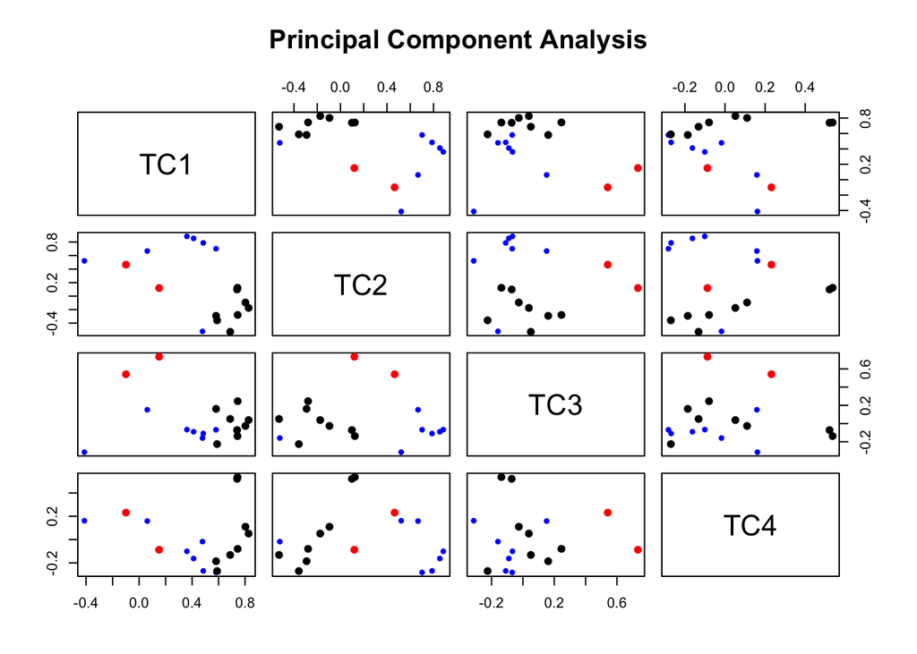

```r
fa.plot(fit.pc1)
```

#### Visualizing the relationship

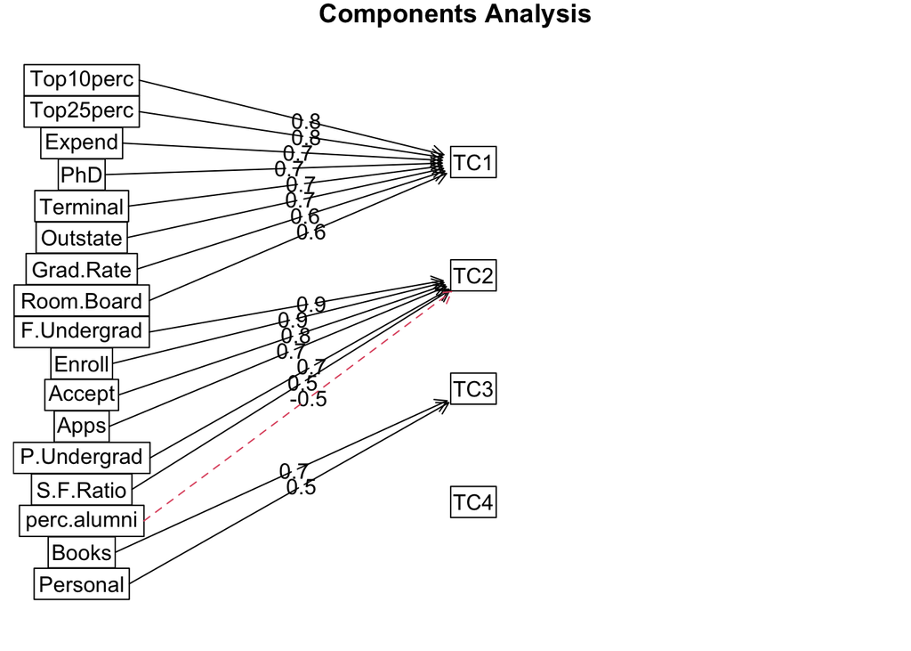

```r
fa.diagram(fit.pc1)
```